# Practical Machine Learning Assignment

A. Chou

22/10/2020

##Introduction

Using devices such as Jawbone Up, Nike FuelBand, and Fitbit it is now possible to collect a large amount of data about personal activity relatively inexpensively. These type of devices are part of the quantified self movement – a group of enthusiasts who take measurements about themselves regularly to improve their health, to find patterns in their behavior, or because they are tech geeks. One thing that people regularly do is quantify how much of a particular activity they do, but they rarely quantify how well they do it. In this project, your goal will be to use data from accelerometers on the belt, forearm, arm, and dumbell of 6 participants. They were asked to perform barbell lifts correctly and incorrectly in 5 different ways. More information is available from the website here: http://groupware.les.inf.puc-rio.br/har (see the section on the Weight Lifting Exercise Dataset).

Six young health participants were asked to perform one set of 10 repetitions of the Unilateral Dumbbell Biceps Curl in five different fashions: exactly according to the specification (Class A), throwing the elbows to the front (Class B), lifting the dumbbell only halfway (Class C), lowering the dumbbell only halfway (Class D) and throwing the hips to the front (Class E).

Class A corresponds to the specified execution of the exercise, while the other 4 classes correspond to common mistakes. Participants were supervised by an experienced weight lifter to make sure the execution complied to the manner they were supposed to simulate. The exercises were performed by six male participants aged between 20-28 years, with little weight lifting experience.

Read more: http:/groupware.les.inf.puc-rio.br/har#ixzz4Tjq6H1IK

The goal here is to predict the “classe” with the help of other predictors.

## Data

The training data for this project are available here:

https://d396qusza40orc.cloudfront.net/predmachlearn/pml-training.csv

The test data are available here:

https://d396qusza40orc.cloudfront.net/predmachlearn/pml-testing.csv

The data for this project come from this source: http://web.archive.org/web/20161224072740/http:/groupware.les.inf.puc-rio.br/har. If you use the document you create for this class for any purpose please cite them as they have been very generous in allowing their data to be used for this kind of assignment.

Loading the packages and the data

```r
library(caret)
```

```r
library(rpart)
library(knitr)
library(rpart.plot)
training_d <- read.csv('pml-training.csv')
test_d <- read.csv('pml-testing.csv')
```

##Cleansing the Data On inspection, we found NA,#DIV/0! and blank values in the data. As these are not valid observed values, we remove them with na.strings parameter.

```r
training_d <- read.csv('pml-training.csv', na.strings = c("NA", "#DIV/0!", ""))
test_d <- read.csv('pml-testing.csv', na.strings = c("NA", "#DIV/0!", ""))
clnIndex <- colSums(is.na(training_d))/nrow(training_d) < 0.95
training.df <-training_d[,clnIndex]
dim(training.df)
```

```
## [1] 19622    60
```

Verifying if NA observations have been removed correctly

```r
colSums(is.na(training.df))/nrow(training.df)
```

```
##                    X            user_name raw_timestamp_part_1
##                    0                    0                    0
## raw_timestamp_part_2       cvtd_timestamp           new_window
##                    0                    0                    0
##           num_window            roll_belt           pitch_belt
##                    0                    0                    0
##             yaw_belt     total_accel_belt         gyros_belt_x
##                    0                    0                    0
##         gyros_belt_y         gyros_belt_z         accel_belt_x
##                    0                    0                    0
##         accel_belt_y         accel_belt_z        magnet_belt_x
##                    0                    0                    0
##        magnet_belt_y        magnet_belt_z             roll_arm
##                    0                    0                    0
##            pitch_arm              yaw_arm      total_accel_arm
##                    0                    0                    0
##          gyros_arm_x          gyros_arm_y          gyros_arm_z
##                    0                    0                    0
##          accel_arm_x          accel_arm_y          accel_arm_z
##                    0                    0                    0
##         magnet_arm_x         magnet_arm_y         magnet_arm_z
##                    0                    0                    0
##        roll_dumbbell       pitch_dumbbell         yaw_dumbbell
##                    0                    0                    0
## total_accel_dumbbell     gyros_dumbbell_x     gyros_dumbbell_y
##                    0                    0                    0
##     gyros_dumbbell_z     accel_dumbbell_x     accel_dumbbell_y
##                    0                    0                    0
##     accel_dumbbell_z    magnet_dumbbell_x    magnet_dumbbell_y
##                    0                    0                    0
##    magnet_dumbbell_z         roll_forearm        pitch_forearm
##                    0                    0                    0
##          yaw_forearm  total_accel_forearm      gyros_forearm_x
##                    0                    0                    0
##      gyros_forearm_y      gyros_forearm_z      accel_forearm_x
##                    0                    0                    0
##      accel_forearm_y      accel_forearm_z     magnet_forearm_x
##                    0                    0                    0
##     magnet_forearm_y     magnet_forearm_z               classe
##                    0                    0                    0
```

```r
colSums(is.na(training.df))
```

```
##                    X            user_name raw_timestamp_part_1
##                    0                    0                    0
## raw_timestamp_part_2       cvtd_timestamp           new_window
##                    0                    0                    0
##           num_window            roll_belt           pitch_belt
##                    0                    0                    0
##             yaw_belt     total_accel_belt         gyros_belt_x
##                    0                    0                    0
##         gyros_belt_y         gyros_belt_z         accel_belt_x
##                    0                    0                    0
##         accel_belt_y         accel_belt_z        magnet_belt_x
##                    0                    0                    0
##        magnet_belt_y        magnet_belt_z             roll_arm
##                    0                    0                    0
##            pitch_arm              yaw_arm      total_accel_arm
##                    0                    0                    0
##          gyros_arm_x          gyros_arm_y          gyros_arm_z
##                    0                    0                    0
##          accel_arm_x          accel_arm_y          accel_arm_z
##                    0                    0                    0
##         magnet_arm_x         magnet_arm_y         magnet_arm_z
##                    0                    0                    0
##        roll_dumbbell       pitch_dumbbell         yaw_dumbbell
##                    0                    0                    0
## total_accel_dumbbell     gyros_dumbbell_x     gyros_dumbbell_y
##                    0                    0                    0
##     gyros_dumbbell_z     accel_dumbbell_x     accel_dumbbell_y
##                    0                    0                    0
##     accel_dumbbell_z    magnet_dumbbell_x    magnet_dumbbell_y
##                    0                    0                    0
##    magnet_dumbbell_z         roll_forearm        pitch_forearm
##                    0                    0                    0
##          yaw_forearm  total_accel_forearm      gyros_forearm_x
##                    0                    0                    0
##      gyros_forearm_y      gyros_forearm_z      accel_forearm_x
##                    0                    0                    0
##      accel_forearm_y      accel_forearm_z     magnet_forearm_x
##                    0                    0                    0
##     magnet_forearm_y     magnet_forearm_z               classe
##                    0                    0                    0
```

Removing the non-predictors from the training set which includes the index, subject name, time and window variables

```r
training.df <- training.df[,-c(1:7)]
cltest_data <- test_d[,-c(1:7)]
```

Partioning the training data into training and cross validation

```r
trainIndex <- createDataPartition(training.df$classe, p=0.75)[[1]]
n_training_data <- training.df[trainIndex,]
cr_training_data <- training.df[-trainIndex,]
dim(n_training_data)
```

```
## [1] 14718    53
```

```r
dim(cr_training_data)
```

```
## [1] 4904   53
```

Changing the test data set into the same

```r
allnames <- names(training.df)
cltest_data <- test_d[,allnames[1:52]]
```

## Algorithm

Predicting with Decision Tree and using confusion matrix

```r
DecisionTree <- train(classe ~., method='rpart', data=n_training_data)
real <- factor(cr_training_data$classe)
DT_prediction<- predict(DecisionTree, cr_training_data)
confusionMatrix(DT_prediction, real)
```

```
## Confusion Matrix and Statistics
##
##           Reference
## Prediction    A    B    C    D    E
##          A 1281  421  412  348  130
##          B   15  299   29  159  120
##          C   97  229  414  297  258
##          D    0    0    0    0    0
##          E    2    0    0    0  393
##
## Overall Statistics
##
##                Accuracy : 0.4867
##                  95% CI : (0.4727, 0.5008)
##     No Information Rate : 0.2845
##     P-Value [Acc > NIR] : < 2.2e-16
##
##                   Kappa : 0.3284
##
##  Mcnemar's Test P-Value : NA
##
## Statistics by Class:
##
##                      Class: A Class: B Class: C Class: D Class: E
## Sensitivity            0.9183  0.31507  0.48421   0.0000  0.43618
## Specificity            0.6264  0.91833  0.78242   1.0000  0.99950
## Pos Pred Value         0.4942  0.48071  0.31969      NaN  0.99494
## Neg Pred Value         0.9507  0.84820  0.87781   0.8361  0.88734
## Prevalence             0.2845  0.19352  0.17435   0.1639  0.18373
## Detection Rate         0.2612  0.06097  0.08442   0.0000  0.08014
## Detection Prevalence   0.5285  0.12684  0.26407   0.0000  0.08055
## Balanced Accuracy      0.7723  0.61670  0.63331   0.5000  0.71784
```

Plot

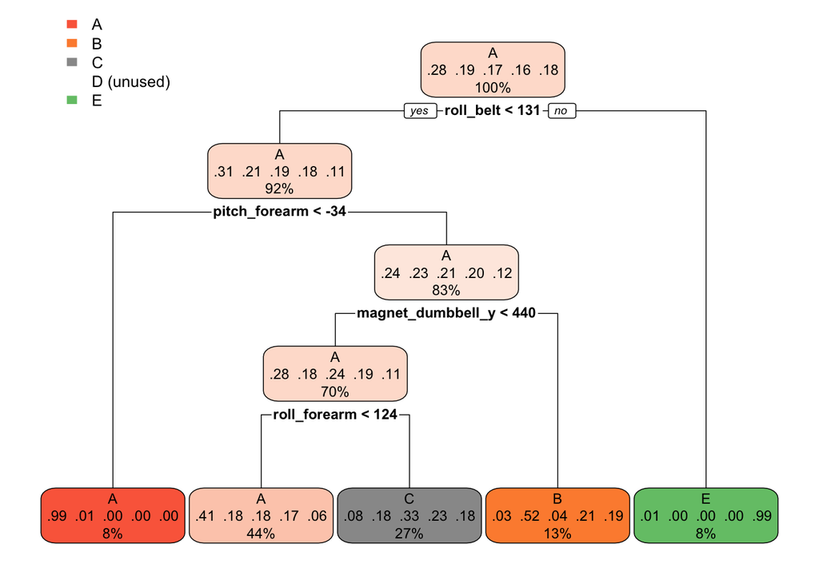

```r
rpart.plot(DecisionTree$finalModel)
```

Using Random Forest

```r
randomForest <- train(classe ~., method='rf', data=n_training_data, ntree=128)
RF_Prediction <- predict(randomForest, cr_training_data)
cMrf<- confusionMatrix(RF_Prediction, real)
cMrf
```

```
## Confusion Matrix and Statistics
##
##           Reference
## Prediction    A    B    C    D    E
##          A 1394    6    0    0    0
##          B    1  943    7    0    0
##          C    0    0  848   16    0
##          D    0    0    0  788    4
##          E    0    0    0    0  897
##
## Overall Statistics
##
##                Accuracy : 0.9931
##                  95% CI : (0.9903, 0.9952)
##     No Information Rate : 0.2845
##     P-Value [Acc > NIR] : < 2.2e-16
##
##                   Kappa : 0.9912
##
##  Mcnemar's Test P-Value : NA
##
## Statistics by Class:
##
##                      Class: A Class: B Class: C Class: D Class: E
## Sensitivity            0.9993   0.9937   0.9918   0.9801   0.9956
## Specificity            0.9983   0.9980   0.9960   0.9990   1.0000
## Pos Pred Value         0.9957   0.9916   0.9815   0.9949   1.0000
## Neg Pred Value         0.9997   0.9985   0.9983   0.9961   0.9990
## Prevalence             0.2845   0.1935   0.1743   0.1639   0.1837
## Detection Rate         0.2843   0.1923   0.1729   0.1607   0.1829
## Detection Prevalence   0.2855   0.1939   0.1762   0.1615   0.1829
## Balanced Accuracy      0.9988   0.9958   0.9939   0.9896   0.9978
```

plot matrix results

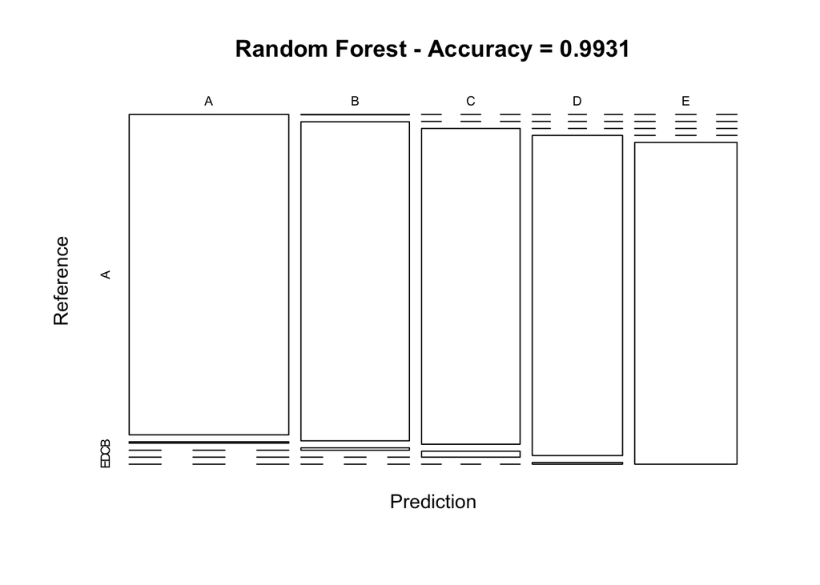

```r
plot(cMrf$table, col = cMrf$byClass, main = paste("Random Forest - Accuracy =",
round(cMrf$overall['Accuracy'], 4)))
```

The accuracy level of the random forest model is 99 percent. The decision tree model has an accuracy of nearly 50 percent Thus, the random forest has better performance and we will apply it to predict the results

```r
predict(randomForest, cltest_data)
```

```
##  [1] B A B A A E D B A A B C B A E E A B B B
## Levels: A B C D E
```